# 03 - DrugBank therapeutic categories analysis

## Overview

This notebook analyzes the distribution of pharmaceutical compounds across food categories based on their DrugBank therapeutic classifications.

## Background

Compounds detected in PTFI that matched to DrugBank were classified by their therapeutic categories. This analysis reveals which pharmaceutical classes are present in different food types and examines the distribution of specific bioactive compounds with pharmaceutical relevance.

## Input data

**`ptfi_data_long.csv`** - PTFI features in long format

- `sample_id`, `sample_foodon_leaf_name`, `metabolite`, `intensity`

**`ptfi_drugs_categories.csv`** - DrugBank therapeutic categories

- `element_id`: Metabolite identifier
- `categories`: Pipe-separated therapeutic categories

**`ptfi_metadata.csv`** - Sample metadata

- `sample_id`, `foodon_level1_name`

## Outputs

1. Heatmap: Mean intensity of therapeutic categories by food category
2. Violin plots: Distribution of selected compounds across food types

```python
import pandas as pd
import numpy as np
import matplotlib.pyplot as plt
import seaborn as sns

# Load data
ptfi_long_df = pd.read_csv("ptfi_data_long.csv")
drug_cats = pd.read_csv('ptfi_drugs_categories.csv', sep=",")
metadata = pd.read_csv('ptfi_metadata.csv')

print(f"Loaded {len(ptfi_long_df)} PTFI features")
print(f"Loaded {len(drug_cats)} metabolites with DrugBank categories")
```

```
Loaded 9814700 PTFI features
Loaded 93 metabolites with DrugBank categories
```

## Data preparation

Filter for metabolites that matched to DrugBank and have therapeutic category annotations.

```python
# Filter for metabolites with DrugBank categories
ptfi_long_df = ptfi_long_df[ptfi_long_df["metabolite"].isin(drug_cats["element_id"])]

# Merge with categories
ptfi_long_df = ptfi_long_df.merge(
    drug_cats[["element_id", "categories"]],
    left_on="metabolite",
    right_on="element_id"
)

# Merge with metadata for FoodOn categories
ptfi_long_df = ptfi_long_df.merge(
    metadata[["sample_id", "foodon_level1_name"]],
    on="sample_id"
)

# Remove multi-component food products
ptfi_long_df = ptfi_long_df[ptfi_long_df["foodon_level1_name"] != "multi-component food product"]

print(f"Filtered to {len(ptfi_long_df)} features with DrugBank categories")
```

```
Filtered to 36600 features with DrugBank categories
```

## Figure 1: Therapeutic categories by food category

Define therapeutic categories of interest and analyze their distribution across food types.

```python
# Define therapeutic categories of interest
therapeutic_list = [
    "Antineoplastic Agents",
    "Anticarcinogenic Agents",
    "Angiogenesis Inhibitors",
    "Topoisomerase II Inhibitors",
    "Radiation-Sensitizing Agents",
    "Protein Kinase Inhibitors",
    "Anticoagulants",
    "Vitamin K Antagonists",
    "Antiplatelet agents",
    "Vasodilating Agents",
    "Hemostatics",
    "Hypnotics and Sedatives",
    "Melatonin Receptor Agonists",
    "Neuroprotective Agents",
    "Anesthetics, Local",
    "TRPV1 Channel Agonists",
    "Monoamine Oxidase A Inhibitors",
    "Immunosuppressive Agents",
    "Glucocorticoids",
    "Antirheumatic Agents",
    "Folic Acid Antagonists",
    "Antipsoriatics",
    "Keratolytic Agents",
    "Photosensitizing Agents",
    "Sclerosing Solutions",
    "Cholelitholytic Agents",
    "Phytoestrogens",
    "Uncoupling Agents",
    "Enzyme Inhibitors",
    "Antioxidants"
]

# Explode pipe-separated categories into separate rows
df_exploded = ptfi_long_df.assign(
    categories=ptfi_long_df['categories'].str.split('|')
).explode('categories').reset_index(drop=True)

# Filter for therapeutic categories of interest
df_exploded_therapeutic = df_exploded[df_exploded["categories"].isin(therapeutic_list)]

print(f"Found {len(df_exploded_therapeutic)} entries for therapeutic categories")
print(f"Unique therapeutic categories: {df_exploded_therapeutic['categories'].nunique()}")
```

```
Found 35624 entries for therapeutic categories
Unique therapeutic categories: 26
```

```python
# Calculate mean intensity by food category and therapeutic category
df_grouped = df_exploded_therapeutic.groupby(
    ["foodon_level1_name", "categories"]
)["intensity"].mean().reset_index()

# Pivot to create heatmap data
heatmap_data = df_grouped.pivot_table(
    index='foodon_level1_name',
    columns='categories',
    values='intensity',
    fill_value=0
)

# Log-transform intensities (add 1 to avoid log(0))
log_heatmap_data = np.log10(heatmap_data + 1)

print("Heatmap dimensions:", log_heatmap_data.shape)
log_heatmap_data.head()
```

```
Heatmap dimensions: (4, 26)
```

| categories foodon_level1_name | Anesthetics, Local | Angiogenesis Inhibitors | Anticarcinogenic Agents | Anticoagulants | Antineoplastic Agents | Antioxidants | Antiplatelet agents | Antipsoriatics | Antirheumatic Agents | Enzyme Inhibitors | ... | Photosensitizing Agents | Phytoestrogens | Protein Kinase Inhibitors | Radiation-Sensitizing Agents | Sclerosing Solutions | TRPV1 Channel Agonists | Topoisomerase II Inhibitors | Uncoupling Agents | Vasodilating Agents | Vitamin K Antagonists |
| --- | --- | --- | --- | --- | --- | --- | --- | --- | --- | --- | --- | --- | --- | --- | --- | --- | --- | --- | --- | --- | --- |
| algal food product | 0.000000 | 0.00000 | 0.000000 | 4.505411 | 0.000000 | 3.058326 | 3.660101 | 0.000000 | 3.262304 | 4.051324 | ... | 0.000000 | 0.000000 | 0.000000 | 0.000000 | 0.000000 | 0.000000 | 0.000000 | 2.846399 | 0.000000 | 4.798324 |
| animal food product | 3.737623 | 0.00000 | 2.006430 | 3.848113 | 3.012759 | 1.559249 | 2.042026 | 0.000000 | 1.649959 | 4.151276 | ... | 0.000000 | 3.396268 | 0.000000 | 0.000000 | 1.716291 | 3.737623 | 3.832556 | 0.000000 | 0.000000 | 4.058124 |
| fungus food product | 0.000000 | 0.00000 | 0.000000 | 3.306639 | 1.912817 | 0.000000 | 0.000000 | 0.000000 | 2.793729 | 3.287356 | ... | 0.000000 | 2.277749 | 0.000000 | 0.000000 | 0.000000 | 0.000000 | 2.753341 | 0.000000 | 0.000000 | 3.607562 |
| plant food product | 3.937793 | 2.81403 | 3.510593 | 3.935822 | 3.409700 | 3.831063 | 4.308787 | 2.948931 | 3.954012 | 4.056573 | ... | 2.948931 | 3.621321 | 2.675153 | 2.948931 | 2.910717 | 3.937793 | 3.656729 | 1.987376 | 2.619254 | 4.074371 |

4 rows × 26 columns

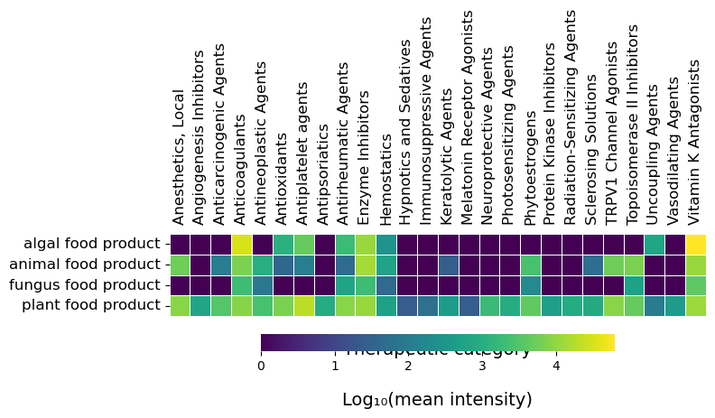

```python
# Create heatmap
fig, ax = plt.subplots(figsize=(14, 4))

sns.heatmap(
    log_heatmap_data,
    annot=False,
    cmap='viridis',
    linewidths=0.5,
    linecolor='white',
    cbar_kws={"shrink": 0.4, 'orientation': 'horizontal', 'location': 'bottom'},
    square=True,
    ax=ax
)

# Formatting
ax.set_xlabel('Therapeutic category', fontsize=14, labelpad=20)
ax.set_ylabel("", fontsize=14, labelpad=20)
ax.tick_params(axis='both', which='major', labelsize=12)

# Rotate x-axis labels and move to top
plt.tick_params(
    axis='x',
    which='major',
    labelsize=12,
    labelbottom=False,
    bottom=False,
    top=False,
    labeltop=True,
    rotation=90
)
plt.yticks(rotation=0)

# Update colorbar label
cbar = ax.collections[0].colorbar
cbar.set_label('Log₁₀(mean intensity)', fontsize=14, labelpad=15)

fig.tight_layout()
#plt.savefig('results/therapeutic_categories_heatmap.png', dpi=300, bbox_inches='tight')
plt.show()
```

## Figure 2: Violin plots for selected compounds

Examine the distribution of specific bioactive compounds across food categories, with emphasis on their presence in animal products.

```python
# Prepare data for violin plots
df_violinplot = ptfi_long_df.groupby(
    ["sample_foodon_leaf_name", "foodon_level1_name", "element_name"]
)["intensity"].mean().reset_index()

print(f"Violin plot data prepared: {len(df_violinplot)} entries")
df_violinplot.head()
```

```
Violin plot data prepared: 21150 entries
```

|  | sample_foodon_leaf_name | foodon_level1_name | element_name | intensity |
| --- | --- | --- | --- | --- |
| 0 | Gala apple (raw) | plant food product | (+)-Catechin\|Catechin | 336445.351652 |
| 1 | Gala apple (raw) | plant food product | (-)-Epigallocatechin gallate | 0.000000 |
| 2 | Gala apple (raw) | plant food product | (R)-2-Benzylsuccinic acid | 0.000000 |
| 3 | Gala apple (raw) | plant food product | 2,4-Dihydroxybenzoic Acid\|2,4-Dihydroxybenzoic... | 0.000000 |
| 4 | Gala apple (raw) | plant food product | 3,4-Dihydroxybenoic acid\|Protocatechuic acid | 0.000000 |

```python
def create_violinplot(df, compound_name, samples_to_mark,
                      figsize=(7, 7), save_path=None, dpi=300):
    """
    Create a violin plot for one compound across food categories,
    marking specific samples in the animal category.

    Parameters:
    -----------
    df : DataFrame
        Data with columns: sample_foodon_leaf_name, foodon_level1_name,
                          element_name, intensity
    compound_name : str
        Name of the compound to plot
    samples_to_mark : list
        List of sample names to highlight in animal products
    figsize : tuple
        Figure size (default (7, 7))
    save_path : str or None
        Path to save the figure
    dpi : int
        DPI for saved figure (default 300)
    """

    # Filter for the compound and intensity > 0
    compound_data = df[
        (df['element_name'] == compound_name) &
        (df['intensity'] > 0)
    ].copy()

    # Remove NaN values
    compound_data = compound_data.dropna(subset=['foodon_level1_name'])

    if len(compound_data) == 0:
        print(f"Warning: No data found for {compound_name}")
        return None, None

    # Create figure
    fig, ax = plt.subplots(figsize=figsize)

    # Define colors for food categories
    category_colors = {
        'animal food product': '#FF6B6B',
        'plant food product': '#4ECDC4',
        'fungus food product': '#45B7D1',
        'algal food product': '#A78CEE'
    }

    # Get categories with data
    categories_with_data = compound_data['foodon_level1_name'].unique()

    # Create violin plot
    sns.violinplot(
        data=compound_data,
        x='foodon_level1_name',
        y='intensity',
        hue='foodon_level1_name',
        ax=ax,
        palette={k: v for k, v in category_colors.items() if k in categories_with_data},
        order=categories_with_data,
        legend=False
    )

    # Set y-axis to start at 0
    ax.set_ylim(bottom=0)

    # Define markers for marked samples
    markers = ['o', 's', '^', 'v', 'D', 'p', '*', 'X']

    # Filter for animal category and samples to mark
    animal_data = compound_data[
        (compound_data['foodon_level1_name'] == 'animal food product') &
        (compound_data['sample_foodon_leaf_name'].isin(samples_to_mark))
    ]

    # Get x position for animal category
    if 'animal food product' in categories_with_data:
        x_pos = list(categories_with_data).index('animal food product')
    else:
        x_pos = None

    # Legend setup
    legend_handles = []
    legend_labels = []

    # Plot marked samples
    if x_pos is not None:
        for i, sample_name in enumerate(samples_to_mark):
            marker = markers[i] if i < len(markers) else 'o'

            # Get data for this specific sample
            sample_data = animal_data[animal_data['sample_foodon_leaf_name'] == sample_name]

            if not sample_data.empty:
                # Plot the points
                ax.scatter(
                    [x_pos] * len(sample_data),
                    sample_data['intensity'],
                    color='darkred',
                    s=100,
                    alpha=0.8,
                    zorder=5,
                    marker=marker,
                    edgecolors='white',
                    linewidth=1.5
                )

                # Add to legend
                handle = plt.Line2D([0], [0], marker=marker, color='w',
                                   markerfacecolor='darkred', markersize=12,
                                   markeredgecolor='white', markeredgewidth=1.5)
                legend_handles.append(handle)
                legend_labels.append(sample_name)

    # Add legend
    if legend_handles:
        ncol = min(len(legend_handles), 3)
        ax.legend(legend_handles, legend_labels,
                 loc='lower center', bbox_to_anchor=(0.5, 1.02),
                 fontsize=14, frameon=True, fancybox=False,
                 ncol=ncol, columnspacing=1.5, handletextpad=0.5)

    # Formatting
    ax.set_xlabel(compound_name, fontsize=16, fontweight='bold')
    ax.set_ylabel('Intensity', fontsize=16, fontweight='bold')
    ax.tick_params(axis='both', which='major', labelsize=14)
    plt.xticks(rotation=90, ha='right')

    plt.tight_layout()

    # Save if path provided
    if save_path is not None:
        import os
        save_dir = os.path.dirname(save_path)
        if save_dir and not os.path.exists(save_dir):
            os.makedirs(save_dir)
        fig.savefig(save_path, format='png', dpi=dpi, bbox_inches='tight')
        print(f"Plot saved to: {save_path}")

    return fig, ax
```

```
Creating violin plot for 4-Hydroxycoumarin...
Plot saved to: results/4-Hydroxycoumarin_violinplot.png
```

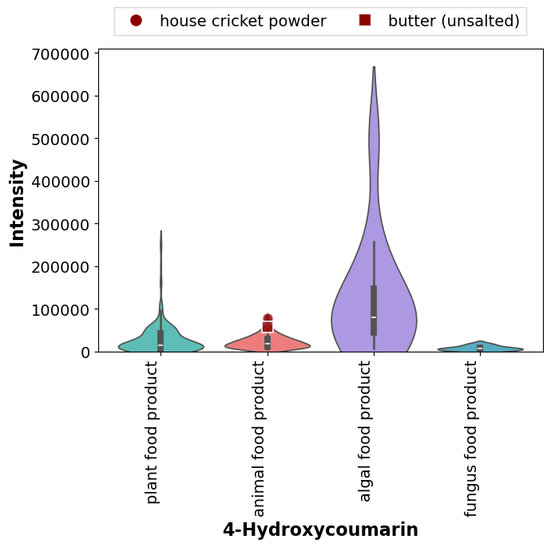

```
Creating violin plot for Daidzein...
Plot saved to: results/Daidzein_violinplot.png
```

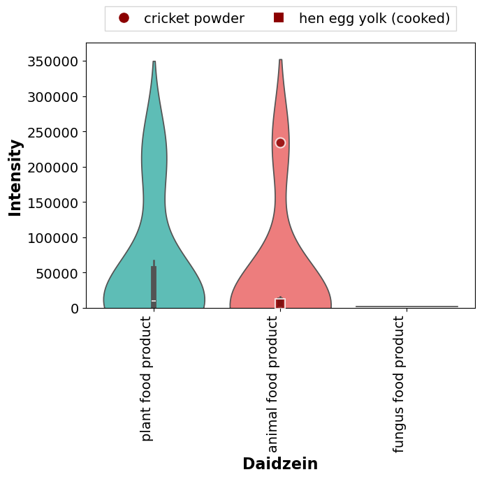

```
Creating violin plot for Salicylic acid...
Plot saved to: results/Salicylic_acid_violinplot.png
```

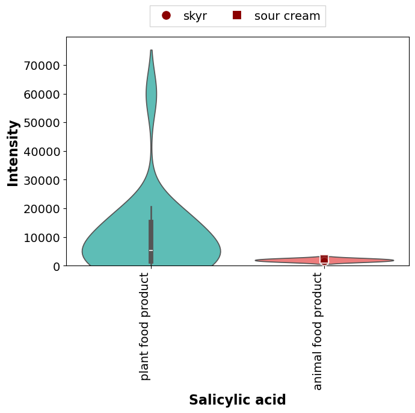

```python
# Define compounds and samples to highlight
compounds_samples = {
    "4-Hydroxycoumarin": ["house cricket powder", "butter (unsalted)"],
    "Daidzein": ["cricket powder", "hen egg yolk (cooked)"],
    "Salicylic acid": ["skyr", "sour cream"]
}

# Create violin plots for each compound
for compound, samples in compounds_samples.items():
    print(f"\nCreating violin plot for {compound}...")
    fig, ax = create_violinplot(
        df=df_violinplot,
        compound_name=compound,
        samples_to_mark=samples,
        figsize=(7, 7),
        save_path=f'results/{compound.replace(" ", "_")}_violinplot.png',
        dpi=300
    )
    plt.show()
```